# Analysing trees simulated by Emily

# setup

[output not shown]

# bnpr estimates

Here we use BNPR in `phylodyn` to estimate the effective population size trajectories for every tree and clade.

[output not shown]

[output cut: 10 more lines]

[output not shown]

# calculating estimates

Here we fit three different models to the BNPR EPS estimates for each clade:

1. log-linear trend (assumes EPS trajectories to be exponential)
2. sigmoid trend (assumes that EPS trajectories saturate)
3. sigmoid trend capped by whole tree EPS estimates (assumes that EPS trajectories saturate somewhere in the 95% CI for the EPS estimates for the whole tree)

# plotting estimates

## Population size estimates at last timepoint

Here we see that, in general, the median EPS estimate for each clade sits below that of the median EPS estimate for the whole tree. Additionally, one sees a good equivalence between the number of samples in a clade and its median EPS estimate.

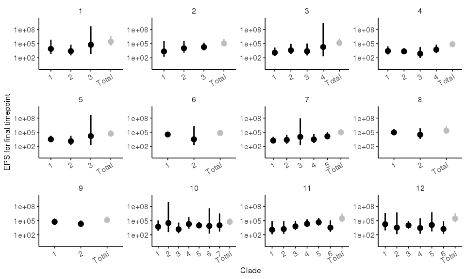

```r
final_pop_size %>%
  ggplot(aes(x = clade_id,y = exp(N),ymin = exp(N025),ymax = exp(N975),
             color = ifelse(clade_id == "Total","Total","NotTotal"))) +
  geom_point() +
  geom_linerange() +
  facet_wrap(~ id,scales = "free") +
  coord_cartesian(ylim = c(1,1e10)) +
  xlab("Clade") +
  ylab("EPS for final timepoint") +
  theme_gerstung(base_size = 6) +
  rotate_x_text(angle = 30) +
  scale_y_continuous(trans = 'log10') +
  scale_color_manual(values = c(Total = "grey",NotTotal = "black"),guide = F)
```

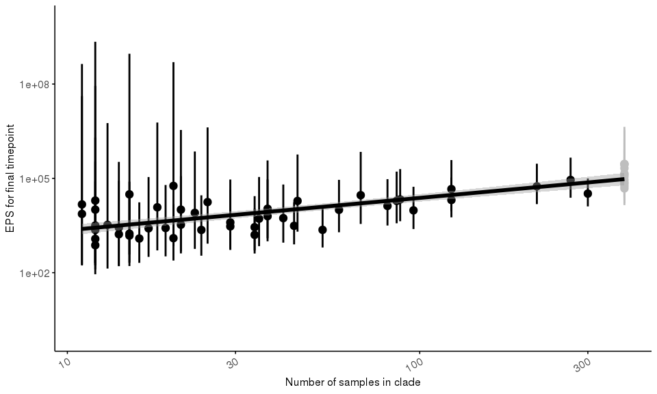

```r
final_pop_size %>%
  ggplot(aes(x = N_samples,y = exp(N),ymin = exp(N025),ymax = exp(N975),
             color = ifelse(clade_id == "Total","Total","NotTotal"))) +
  geom_point() +
  geom_linerange() +
  geom_smooth(color = "black",method = "lm") +
  xlab("Number of samples in clade") +
  ylab("EPS for final timepoint") +
  theme_gerstung(base_size = 6) +
  rotate_x_text(angle = 30) +
  scale_x_continuous(trans = 'log10') +
  scale_y_continuous(trans = 'log10') +
  coord_cartesian(ylim = c(1,1e10)) +
  scale_color_manual(values = c(Total = "grey",NotTotal = "black"),guide = F)
```

Below we have a simple linear test for $EPS = log(number \ of \ samples)$

```r
lm(N ~ log(N_samples),data = subset(final_pop_size,clade_id != "Total")) %>%
  summary
```

```
##
## Call:
## lm(formula = N ~ log(N_samples), data = subset(final_pop_size,
##     clade_id != "Total"))
##
## Residuals:
##     Min      1Q  Median      3Q     Max
## -1.5051 -0.7485 -0.2056  0.7403  2.5112
##
## Coefficients:
##                Estimate Std. Error t value Pr(>|t|)
## (Intercept)      6.0180     0.5703  10.552  9.4e-14 ***
## log(N_samples)   0.8119     0.1612   5.038  8.1e-06 ***
## ---
## Signif. codes:  0 '***' 0.001 '**' 0.01 '*' 0.05 '.' 0.1 ' ' 1
##
## Residual standard error: 0.9778 on 45 degrees of freedom
## Multiple R-squared:  0.3606, Adjusted R-squared:  0.3464
## F-statistic: 25.38 on 1 and 45 DF,  p-value: 8.104e-06
```

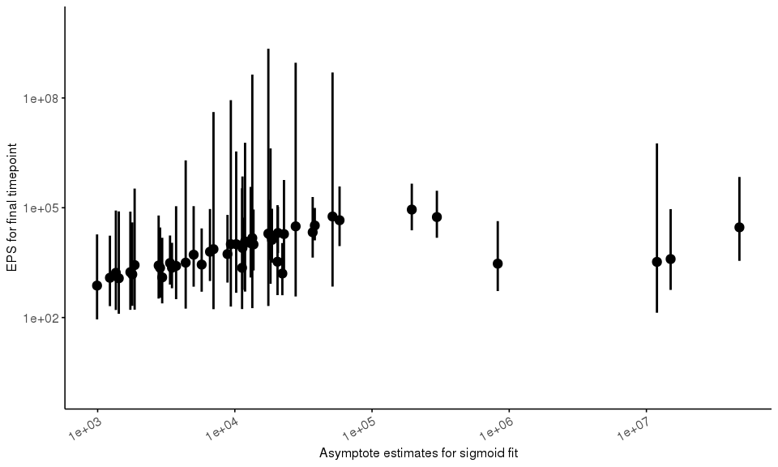

```r
pop_size_eps_merge %>%
  ggplot(aes(x = no_cap,y = exp(N),ymin = exp(N025),ymax = exp(N975),
             color = ifelse(clade_id == "Total","Total","NotTotal"))) +
  geom_point() +
  geom_linerange() +
  xlab("Asymptote estimates for sigmoid fit") +
  ylab("EPS for final timepoint") +
  theme_gerstung(base_size = 6) +
  rotate_x_text(angle = 30) +
  scale_x_continuous(trans = 'log10') +
  scale_y_continuous(trans = 'log10') +
  coord_cartesian(ylim = c(1,1e10)) +
  scale_color_manual(values = c(Total = "grey",NotTotal = "black"),guide = F)
```

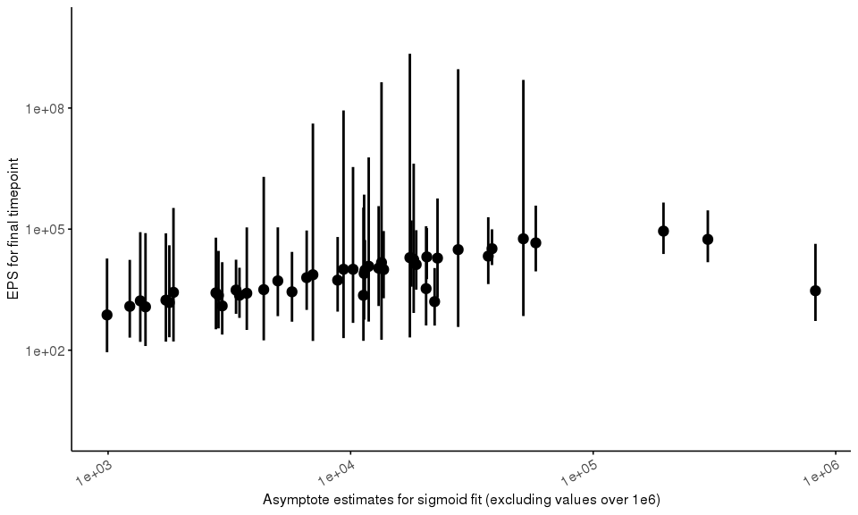

```r
pop_size_eps_merge %>%
  subset(no_cap < 1e6) %>%
  ggplot(aes(x = no_cap,y = exp(N),ymin = exp(N025),ymax = exp(N975),
             color = ifelse(clade_id == "Total","Total","NotTotal"))) +
  geom_point() +
  geom_linerange() +
  xlab("Asymptote estimates for sigmoid fit (excluding values over 1e6)") +
  ylab("EPS for final timepoint") +
  theme_gerstung(base_size = 6) +
  rotate_x_text(angle = 30) +
  scale_x_continuous(trans = 'log10') +
  scale_y_continuous(trans = 'log10') +
  coord_cartesian(ylim = c(1,1e10)) +
  scale_color_manual(values = c(Total = "grey",NotTotal = "black"),guide = F)
```

Below we have a simple linear test for $EPS = log(asymptote)$ and also excluding asymptote values > 1e6.

```r
lm(N ~ log(no_cap),data = pop_size_eps_merge) %>%
  summary
```

```
##
## Call:
## lm(formula = N ~ log(no_cap), data = pop_size_eps_merge)
##
## Residuals:
##      Min       1Q   Median       3Q      Max
## -2.25008 -0.75789  0.04401  0.90592  2.01587
##
## Coefficients:
##             Estimate Std. Error t value Pr(>|t|)
## (Intercept)  6.49471    0.68203   9.523 2.35e-12 ***
## log(no_cap)  0.23705    0.06822   3.475  0.00114 **
## ---
## Signif. codes:  0 '***' 0.001 '**' 0.01 '*' 0.05 '.' 0.1 ' ' 1
##
## Residual standard error: 1.086 on 45 degrees of freedom
## Multiple R-squared:  0.2116, Adjusted R-squared:  0.194
## F-statistic: 12.07 on 1 and 45 DF,  p-value: 0.001143
```

```r
lm(N ~ log(no_cap),data = subset(pop_size_eps_merge,no_cap < 1e6)) %>%
  summary
```

```
##
## Call:
## lm(formula = N ~ log(no_cap), data = subset(pop_size_eps_merge,
##     no_cap < 1e+06))
##
## Residuals:
##     Min      1Q  Median      3Q     Max
## -3.5261 -0.3228  0.1945  0.5255  1.1656
##
## Coefficients:
##             Estimate Std. Error t value Pr(>|t|)
## (Intercept)  3.04419    0.82300   3.699 0.000623 ***
## log(no_cap)  0.62227    0.08802   7.069 1.16e-08 ***
## ---
## Signif. codes:  0 '***' 0.001 '**' 0.01 '*' 0.05 '.' 0.1 ' ' 1
##
## Residual standard error: 0.8365 on 42 degrees of freedom
## Multiple R-squared:  0.5434, Adjusted R-squared:  0.5325
## F-statistic: 49.98 on 1 and 42 DF,  p-value: 1.157e-08
```

```r
lm(N ~ log(cap),data = pop_size_eps_merge) %>%
  summary
```

```
##
## Call:
## lm(formula = N ~ log(cap), data = pop_size_eps_merge)
##
## Residuals:
##      Min       1Q   Median       3Q      Max
## -2.03921 -0.95323 -0.04699  0.99696  2.28433
##
## Coefficients:
##             Estimate Std. Error t value Pr(>|t|)
## (Intercept)   6.6337     1.5437   4.297 9.14e-05 ***
## log(cap)      0.2036     0.1442   1.412    0.165
## ---
## Signif. codes:  0 '***' 0.001 '**' 0.01 '*' 0.05 '.' 0.1 ' ' 1
##
## Residual standard error: 1.197 on 45 degrees of freedom
## Multiple R-squared:  0.04244,    Adjusted R-squared:  0.02116
## F-statistic: 1.995 on 1 and 45 DF,  p-value: 0.1647
```

```r
lm(N ~ log(cap),data = subset(pop_size_eps_merge,cap < 1e6)) %>%
  summary
```

```
##
## Call:
## lm(formula = N ~ log(cap), data = subset(pop_size_eps_merge,
##     cap < 1e+06))
##
## Residuals:
##     Min      1Q  Median      3Q     Max
## -2.1009 -0.9573  0.1536  0.9059  1.8612
##
## Coefficients:
##             Estimate Std. Error t value Pr(>|t|)
## (Intercept)   2.0898     2.6500   0.789   0.4348
## log(cap)      0.6461     0.2549   2.535   0.0151 *
## ---
## Signif. codes:  0 '***' 0.001 '**' 0.01 '*' 0.05 '.' 0.1 ' ' 1
##
## Residual standard error: 1.153 on 42 degrees of freedom
## Multiple R-squared:  0.1327, Adjusted R-squared:  0.1121
## F-statistic: 6.427 on 1 and 42 DF,  p-value: 0.01505
```

## plotting coefficients for linear and sigmoidal fits

We exclude from the subsequent analysis any clades whose growth coefficient was < 0.

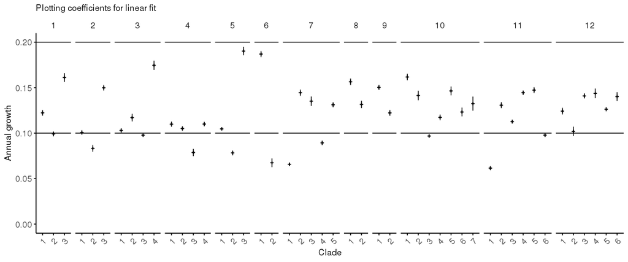

```r
all_growth_estimates_values_df %>%
  group_by(id) %>%
  mutate(clade = factor(clade)) %>%
  mutate(clade_N = seq(1,length(clade))) %>%
  ggplot(aes(x = clade,y = exp(linear)-1,
             ymin = exp(linear - linear_se)-1,ymax = exp(linear + linear_se)-1)) +
  geom_hline(yintercept = 0.1,size = 0.25) +
  geom_hline(yintercept = 0.2,size = 0.25) +
  geom_linerange(size = 0.25) +
  geom_point(size = 0.25,shape = 3) +
  facet_grid(~ id,scales = "free_x",space = "free_x") +
  theme_gerstung(base_size = 6) +
  coord_cartesian(ylim = c(0,NA)) +
  ylab("Annual growth") +
  xlab("Clade") +
  rotate_x_text(angle = 45) +
  ggtitle("Plotting coefficients for linear fit") +
  ggsave("figures/model_ch/trees/mitchell_simulated_coefficients_linear.pdf",
         height = 2,
         width = 4)
```

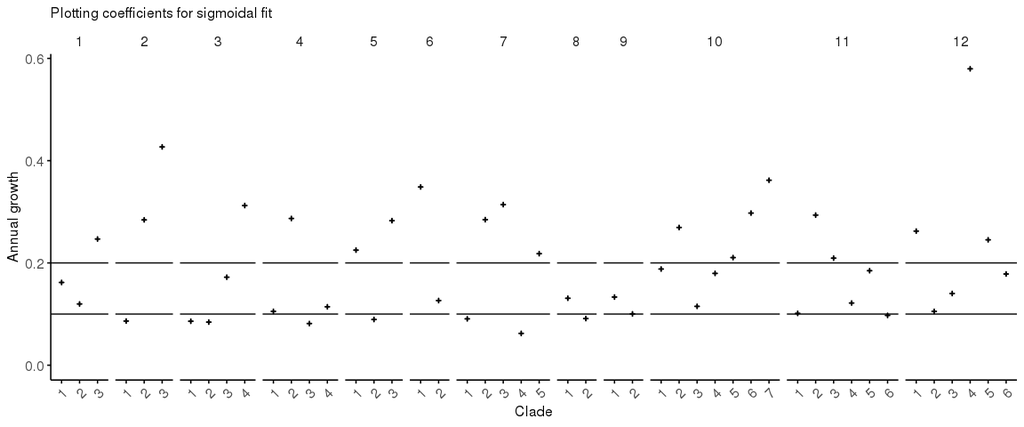

```r
all_growth_estimates_values_df %>%
  group_by(id) %>%
  mutate(clade = factor(clade)) %>%
  mutate(clade_N = seq(1,length(clade))) %>%
  ggplot(aes(x = clade,y = exp(nonlinear)-1)) +
  geom_hline(yintercept = 0.1,size = 0.25) +
  geom_hline(yintercept = 0.2,size = 0.25) +
  geom_point(size = 0.25,shape = 3) +
  facet_grid(~ id,scales = "free_x",space = "free_x") +
  theme_gerstung(base_size = 6) +
  coord_cartesian(ylim = c(0,NA)) +
  ylab("Annual growth") +
  xlab("Clade") +
  rotate_x_text(angle = 45) +
  ggtitle("Plotting coefficients for sigmoidal fit") +
  ggsave("figures/model_ch/trees/mitchell_simulated_coefficients_nonlinear.pdf",
         height = 2,
         width = 4)
```

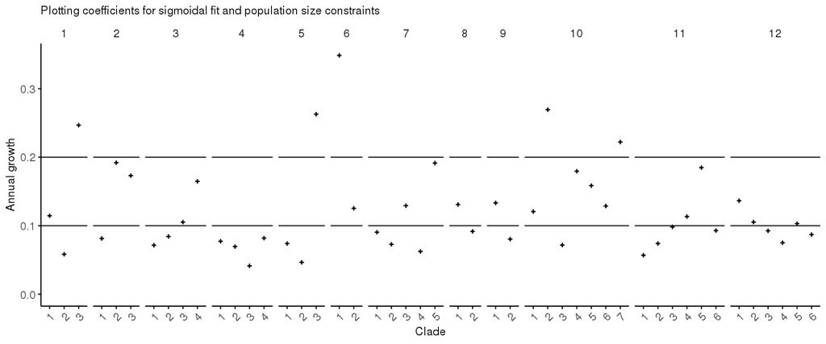

```r
all_growth_estimates_values_df %>%
  group_by(id) %>%
  mutate(clade = factor(clade)) %>%
  mutate(clade_N = seq(1,length(clade))) %>%
  ggplot(aes(x = clade,y = exp(nonlinear_samecap)-1)) +
  geom_hline(yintercept = 0.1,size = 0.25) +
  geom_hline(yintercept = 0.2,size = 0.25) +
  geom_point(size = 0.25,shape = 3) +
  facet_grid(~ id,scales = "free_x",space = "free_x") +
  theme_gerstung(base_size = 6) +
  coord_cartesian(ylim = c(0,NA)) +
  ylab("Annual growth") +
  xlab("Clade") +
  rotate_x_text(angle = 45) +
  ggtitle("Plotting coefficients for sigmoidal fit and population size constraints") +
  ggsave("figures/model_ch/trees/mitchell_simulated_coefficients_nonlinear_cap.pdf",
         height = 2,
         width = 4)
```

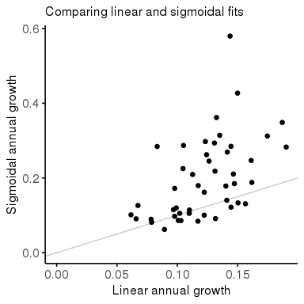

```r
all_growth_estimates_values_df %>%
  group_by(id) %>%
  mutate(clade = factor(clade)) %>%
  mutate(clade_N = seq(1,length(clade))) %>%
  ggplot(aes(x = exp(linear)-1,y = exp(nonlinear)-1)) +
  geom_abline(colour = "grey80",size = 0.25) +
  geom_point(size = 0.5) +
  coord_cartesian(xlim = c(0,NA),ylim = c(0,NA)) +
  theme_gerstung(base_size = 6) +
  ggtitle("Comparing linear and sigmoidal fits") +
  xlab("Linear annual growth") +
  ylab("Sigmoidal annual growth")
```

## growth rates when using first (early) or last (late) 20% of the data

Here we can observe the quite clear distinction between early and late growth -

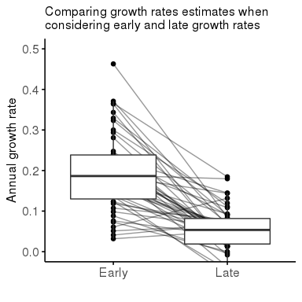

```r
all_growth_estimates_values_df %>%
  gather(key = "key",value = "value",linear_early,linear_late) %>%
  mutate(key = ifelse(key == "linear_early","Early","Late")) %>%
  ggplot(aes(x = key,y = exp(value) - 1)) +
  geom_point(size = 0.5) +
  geom_line(aes(group = paste(id,clade)),alpha = 0.4,size = 0.25) +
  geom_boxplot(size = 0.25,outlier.colour = NA) +
  theme_gerstung(base_size = 6) +
  coord_cartesian(ylim = c(0,0.5)) +
  ylab("Annual growth rate") +
  xlab("") +
  ggtitle("Comparing growth rates estimates when\nconsidering early and late growth rates") +
  ggsave("figures/model_ch/trees/mitchell_simulated_coefficients_nonlinear_cap_early_late.pdf",
         height = 2.5,
         width = 2)
```

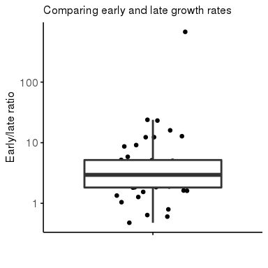

```r
all_growth_estimates_values_df %>%
  subset(linear_late > 0) %>%
  mutate(ratio = linear_early / linear_late) %>%
  ggplot(aes(x = "",y = ratio)) +
  geom_point(position = position_jitter(width = 0.2),size = 0.5) +
  geom_boxplot(outlier.alpha = 0) +
  theme_gerstung(base_size = 6) +
  ggtitle("Comparing early and late growth rates") +
  ylab("Early/late ratio") +
  xlab("") +
  scale_y_continuous(trans = 'log10')
```

## trajectories for different types of fit

Inspecting these reveals a relevant aspect - the saturation of different clades is not bounded by the EPS estimates for the different trees. In other words, the saturation in for the BNPR estimates is not dependent on the maximum population size for the tree. As such, even though there is a good association between number of samples in each clade and EPS median estimate, the point of saturation per si should be avoided as a proxy for VAF.

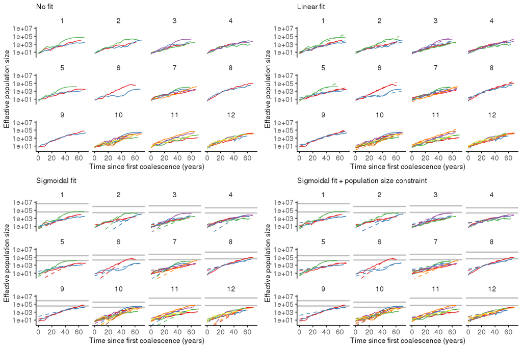

```r
plot_list <- list()
plot_list$no_fit <- all_growth_estimates_df %>%
  group_by(clade,id) %>%
  mutate(X = X - min(X)) %>%
  subset(n_samples >= 5) %>%
  ggplot(aes(x = X,y = exp(Y),colour = as.factor(clade))) +
  geom_line(size = 0.25) +
  facet_wrap(~ id) +
  scale_color_manual(breaks = c(1:18),
                     values = c(colours[1:18]),
                     guide = F) +
  scale_y_continuous(trans = 'log10') +
  theme_gerstung(base_size = 6) +
  coord_cartesian(ylim = c(1,1e7)) +
  xlab("Time since first coalescence (years)") +
  ylab("Effective population size") +
  ggtitle("No fit") +
  ggsave("figures/model_ch/trees/mitchell_simulated_trajectories.pdf",
         height = 2.5,
         width = 3)

plot_list$linear <- all_growth_estimates_df %>%
  group_by(clade,id) %>%
  mutate(X = X - min(X)) %>%
  subset(n_samples >= 5) %>%
  ggplot(aes(x = X,y = exp(pred_l),colour = as.factor(clade))) +
  geom_line(aes(y = exp(Y)),size = 0.25) +
  geom_line(size = 0.25,linetype = 2) +
  facet_wrap(~ id) +
  scale_color_manual(breaks = c(1:18),
                     values = c(colours[1:18]),
                     guide = F) +
  scale_y_continuous(trans = 'log10') +
  theme_gerstung(base_size = 6) +
  coord_cartesian(ylim = c(1,1e7)) +
  xlab("Time since first coalescence (years)") +
  ylab("Effective population size") +
  ggtitle("Linear fit") +
  ggsave("figures/model_ch/trees/mitchell_simulated_trajectories_predicted.pdf",
         height = 2.5,
         width = 3)

nl_sc_pop_size <- data.frame(
  clade = rep(NA,length(individual_bnpr_estimates)),
  id = 1:length(individual_bnpr_estimates),
  clade_id = rep("Total",4),
  N = sapply(individual_bnpr_estimates,function(x) log(x$summary$quant0.5[1])),
  N025 = sapply(individual_bnpr_estimates,function(x) log(x$summary$quant0.025[1])),
  N975 = sapply(individual_bnpr_estimates,function(x) log(x$summary$quant0.975[1])),
  n_samples = sapply(trees_simulated,function(x) length(x$tip.label))
)

plot_list$sigmoidal <- all_growth_estimates_df %>%
  group_by(clade,id) %>%
  mutate(X = X - min(X)) %>%
  subset(n_samples >= 5) %>%
  ggplot(aes(x = X,y = pred_nl,colour = as.factor(clade))) +
  geom_hline(aes(yintercept = exp(N025)),alpha = 0.25,
             data = nl_sc_pop_size) +
  geom_hline(aes(yintercept = exp(N975)),alpha = 0.25,
             data = nl_sc_pop_size) +
  geom_line(aes(y = exp(Y)),size = 0.25) +
  geom_line(size = 0.25,linetype = 2) +
  facet_wrap(~ id) +
  scale_color_manual(breaks = c(1:18),
                     values = c(colours[1:18]),
                     guide = F) +
  scale_y_continuous(trans = 'log10') +
  theme_gerstung(base_size = 6) +
  coord_cartesian(ylim = c(1,1e7)) +
  xlab("Time since first coalescence (years)") +
  ylab("Effective population size") +
  ggtitle("Sigmoidal fit") +
  ggsave("figures/model_ch/trees/mitchell_simulated_trajectories_predicted_nl.pdf",
         height = 2.5,
         width = 3)

plot_list$capped_sigmoidal <- all_growth_estimates_df %>%
  group_by(clade,id) %>%
  mutate(X = X - min(X)) %>%
  subset(n_samples >= 5) %>%
  ggplot(aes(x = X,y = pred_nl_sc,colour = as.factor(clade))) +
  geom_hline(aes(yintercept = exp(N025)),alpha = 0.25,
             data = nl_sc_pop_size) +
  geom_hline(aes(yintercept = exp(N975)),alpha = 0.25,
             data = nl_sc_pop_size) +
  geom_line(aes(y = exp(Y)),size = 0.25) +
  geom_line(size = 0.25,linetype = 2) +
  facet_wrap(~ id) +
  scale_color_manual(breaks = c(1:18),
                     values = c(colours[1:18]),
                     guide = F) +
  scale_y_continuous(trans = 'log10') +
  theme_gerstung(base_size = 6) +
  coord_cartesian(ylim = c(1,1e7)) +
  xlab("Time since first coalescence (years)") +
  ylab("Effective population size") +
  ggtitle("Sigmoidal fit + population size constraint") +
  ggsave("figures/model_ch/trees/mitchell_simulated_trajectories_predicted_nl_sc.pdf",
         height = 2.5,
         width = 3)

plot_grid(plotlist = plot_list,nrow = 2)
```

## trees and trajectories

Here we observe each one of the trees and the relevant BNPR trajectories.

[output not shown]

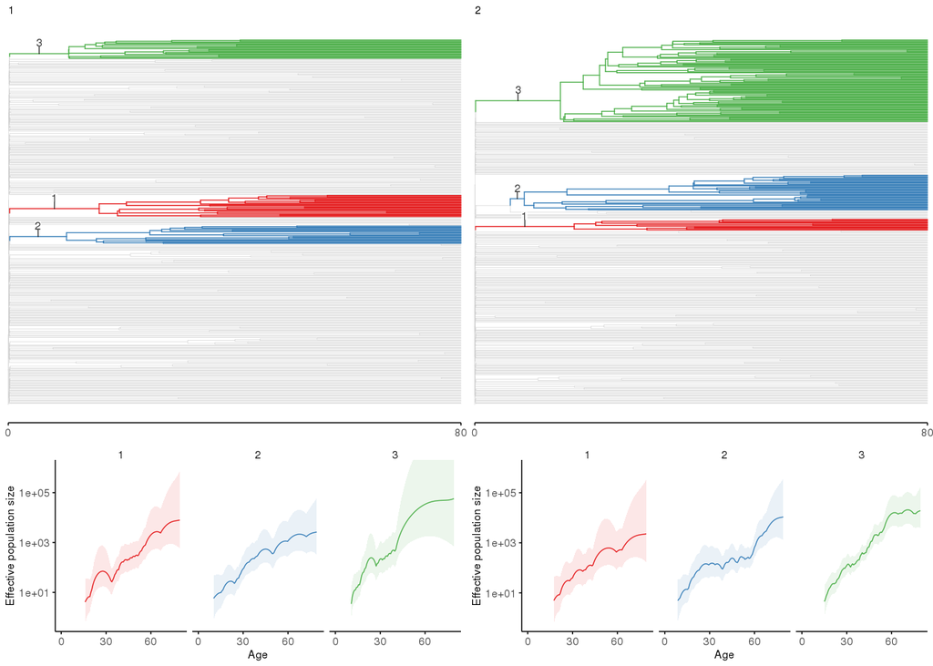

```r
plot_grid(
  plot_grid(all_plots[[1]]$tree,all_plots[[1]]$bnpr,ncol = 1,rel_heights = c(1,0.5)),
  plot_grid(all_plots[[2]]$tree,all_plots[[2]]$bnpr,ncol = 1,rel_heights = c(1,0.5)),
  nrow = 1
) +
  ggsave("figures/model_ch/trees/mitchell_simulated_1.pdf",
         height = 6,
         width = 7)
```

[output not shown]

[output cut: 8 more lines]

[output not shown]

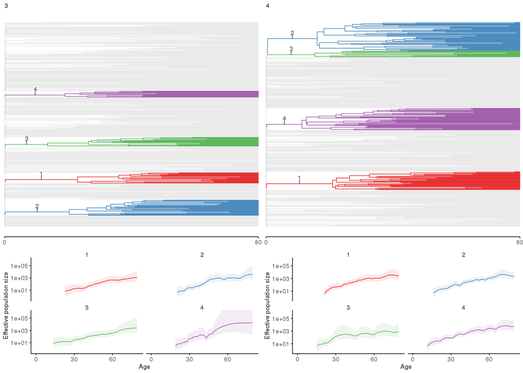

```r
plot_grid(
  plot_grid(all_plots[[3]]$tree,all_plots[[3]]$bnpr,ncol = 1,rel_heights = c(1,0.5)),
  plot_grid(all_plots[[4]]$tree,all_plots[[4]]$bnpr,ncol = 1,rel_heights = c(1,0.5)),
  nrow = 1
) +
  ggsave("figures/model_ch/trees/mitchell_simulated_2.pdf",
         height = 6,
         width = 7)
```

[output not shown]

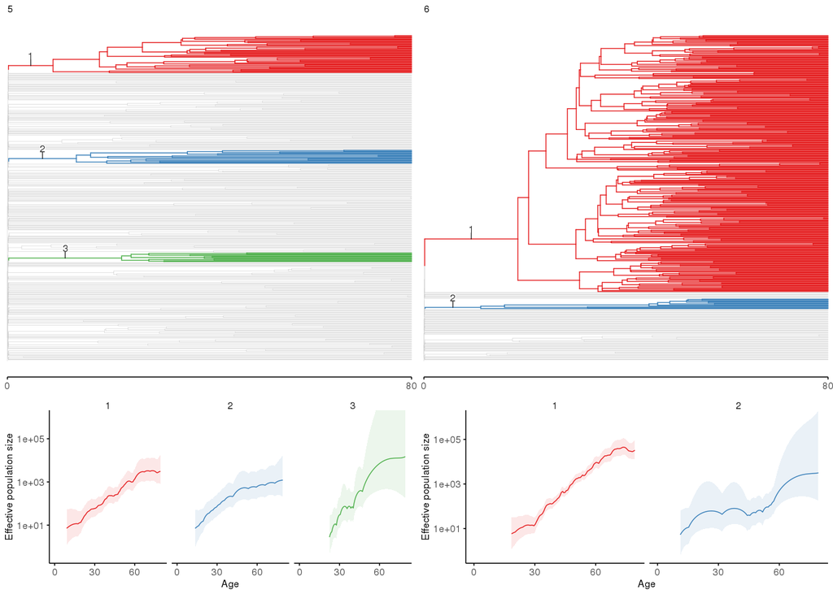

```r
plot_grid(
  plot_grid(all_plots[[5]]$tree,all_plots[[5]]$bnpr,ncol = 1,rel_heights = c(1,0.5)),
  plot_grid(all_plots[[6]]$tree,all_plots[[6]]$bnpr,ncol = 1,rel_heights = c(1,0.5)),
  nrow = 1
) +
  ggsave("figures/model_ch/trees/mitchell_simulated_3.pdf",
         height = 6,
         width = 7)
```

[output not shown]

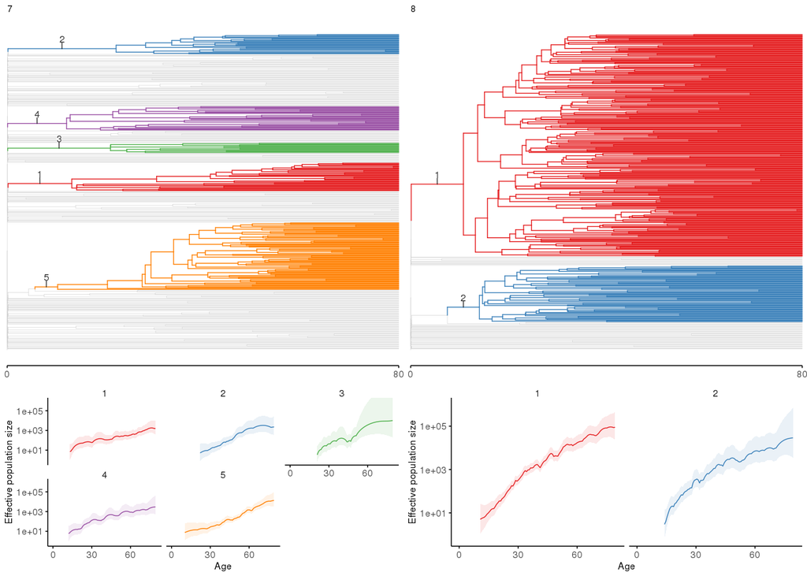

```r
plot_grid(
  plot_grid(all_plots[[7]]$tree,all_plots[[7]]$bnpr,ncol = 1,rel_heights = c(1,0.5)),
  plot_grid(all_plots[[8]]$tree,all_plots[[8]]$bnpr,ncol = 1,rel_heights = c(1,0.5)),
  nrow = 1
) +
  ggsave("figures/model_ch/trees/mitchell_simulated_4.pdf",
         height = 6,
         width = 7)
```

[output not shown]

[output cut: 16 more lines]

[output not shown]

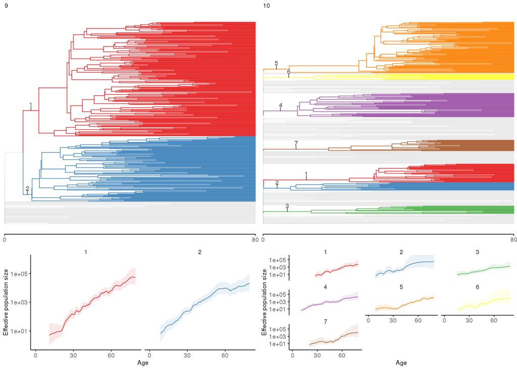

```r
plot_grid(
  plot_grid(all_plots[[9]]$tree,all_plots[[9]]$bnpr,ncol = 1,rel_heights = c(1,0.5)),
  plot_grid(all_plots[[10]]$tree,all_plots[[10]]$bnpr,ncol = 1,rel_heights = c(1,0.5)),
  nrow = 1
) +
  ggsave("figures/model_ch/trees/mitchell_simulated_5.pdf",
         height = 6,
         width = 7)
```

[output not shown]

[output cut: 40 more lines]

[output not shown]

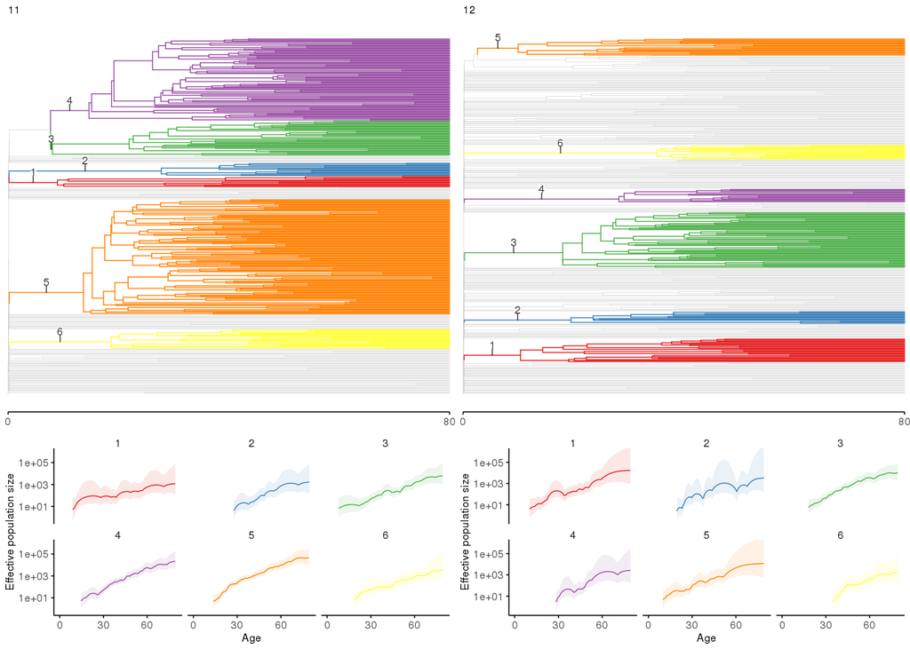

```r
plot_grid(
  plot_grid(all_plots[[11]]$tree,all_plots[[11]]$bnpr,ncol = 1,rel_heights = c(1,0.5)),
  plot_grid(all_plots[[12]]$tree,all_plots[[12]]$bnpr,ncol = 1,rel_heights = c(1,0.5)),
  nrow = 1
) +
  ggsave("figures/model_ch/trees/mitchell_simulated_6.pdf",
         height = 6,
         width = 7)
```